# Exploration of bivalent domains

Kaisu Hiltunen

```r
suppressPackageStartupMessages({
  library(AnnotationHub)
  library(ensembldb)
  library(GenomicRanges)
  library(epiwraps)
  library(rtracklayer)
  library(ggplot2)
  library(R.utils)
})
```

# Assignment week5

Using the peaks downloaded last week, we identify bivalent domains (H3K27me3 + H3K4me3) in mouse embryonic stem cells (mESC).

Histone modifications

- H3K4me3, and
- H3K27me3

Cell lines

- mESC
- forebrain cells from 15.5 days old mus musculus

In this assignment we look at what happens to these regions in differentiated cell lines. I chose the forebrain cells from 15.5 days old Mus musculus embryon (B6NCrl). Following code snippet downloads the files for peaks in this cell type:

```r
#H3K27me3 ChIP-seq on embryonic 15.5 day mouse forebrain
download.file("https://www.encodeproject.org/files/ENCFF307UVN/@@download/ENCFF307UVN.bed.gz",
 "peaks/brain_H3K27me3.bed.gz")
gunzip("peaks/brain_H3K27me3.bed.gz")

#H3K27ac ChIP-seq on embryonic 15.5 day mouse forebrain
#download.file("https://www.encodeproject.org/files/ENCFF433OHF/@@download/ENCFF433OHF.bed.gz","peaks/brain_H3K27ac.bed.gz")
#gunzip("peaks/brain_H3K27ac.bed.gz")

#H3K4me3 Mus musculus strain B6NCrl forebrain tissue embryo (15.5 days)
download.file("https://www.encodeproject.org/files/ENCFF112LTJ/@@download/ENCFF112LTJ.bed.gz",  "peaks/brain_H3K4me3.bed.gz")
gunzip("peaks/brain_H3K4me3.bed.gz")

#H3K4me1 ChIP-seq on embryonic 15.5 day mouse forebrain
#download.file("https://www.encodeproject.org/files/ENCFF871XIM/@@download/ENCFF871XIM.bed.gz",  "peaks/brain_H3K4me1.bed.gz")
#gunzip("peaks/brain_H3K4me1.bed.gz")
```

```r
#how to iterate through the different files:
#first list the files
peakfiles <- list.files("peaks",full.names=TRUE)
#then give them meaningful names
names(peakfiles) <- gsub("\\.bed","",basename(peakfiles))
# then loop through them and read them:
peaks <- lapply(peakfiles, FUN=rtracklayer::import, format="narrowPeak")
```

We can summarise the peak overlaps with regionOverlaps(). E.g., from the table below we can see there are 3920 brain_H3K4me3 peaks overlapping brain_H3K27me3 regions.

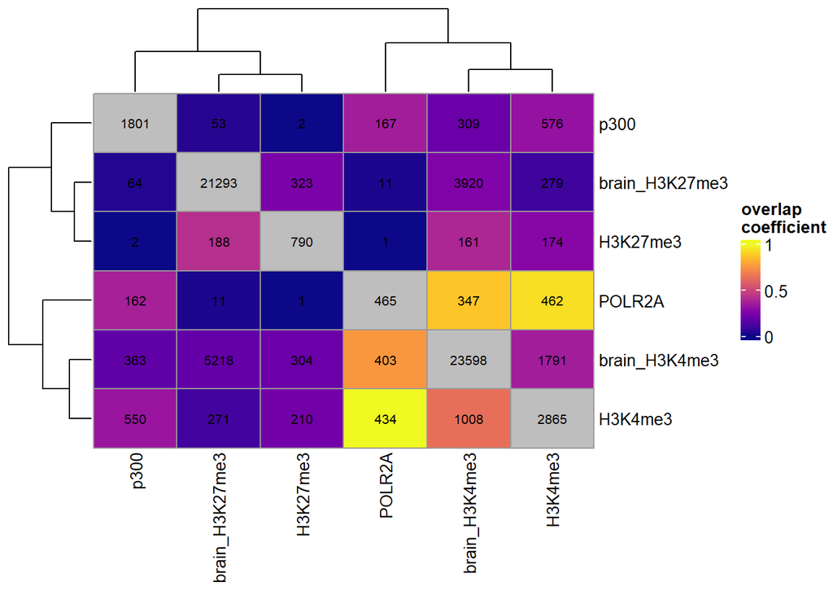

```r
regionOverlaps(peaks)
```

```r
#finding the bivalent domains with H3K27me3 + H3K4me3 in mESC
lapply(peaks, FUN=function(x) sum(overlapsAny(peaks$H3K4me3,x)))
```

```
## $brain_H3K27me3
## [1] 279
##
## $brain_H3K4me3
## [1] 1791
##
## $H3K27me3
## [1] 174
##
## $H3K4me3
## [1] 2865
##
## $p300
## [1] 576
##
## $POLR2A
## [1] 462
```

```r
#Using subsetByOverlaps(subject, query) to subset the overlapping peaks
peaks$mESC_bivalent_doms<-subsetByOverlaps(x=peaks$H3K4me3,ranges=peaks$H3K27me3)
#Below gives us the number of ranges aka 174
#length(peaks$mESC_bivalent_doms)
```

We can see above that 174 H3K27me3 regions are overlapped by H3K4me3 in mESC.

```r
lapply(peaks, FUN=function(x) sum(overlapsAny(peaks$brain_H3K4me3,x)))
```

```
## $brain_H3K27me3
## [1] 3920
##
## $brain_H3K4me3
## [1] 23598
##
## $H3K27me3
## [1] 161
##
## $H3K4me3
## [1] 1008
##
## $p300
## [1] 309
##
## $POLR2A
## [1] 347
##
## $mESC_bivalent_doms
## [1] 127
```

And as seen above, in the forebrain, the same number is 3920 (H3K27me3 regions overlapped by H3K4me3).

```r
#saving the 3920 bivalent regions in the brain
peaks$brain_bivalent_doms<-subsetByOverlaps(x=peaks$brain_H3K4me3,ranges=peaks$brain_H3K27me3)
```

From these 3920 regions, 79 are from the original bivalent domains that we saw in the mESC.

```r
#saving the bivalent domains shared by the two different cell lines
peaks$shared_bivalent_doms<-subsetByOverlaps(peaks$brain_bivalent_doms,peaks$mESC_bivalent_doms)
#printing the number for checking the result
length(peaks$shared_bivalent_doms)
```

```
## [1] 79
```

Similar number (85) can also be seen in the upset plot. This is a bit larger result, possibly due to differing counting method from subsetByOverlaps.

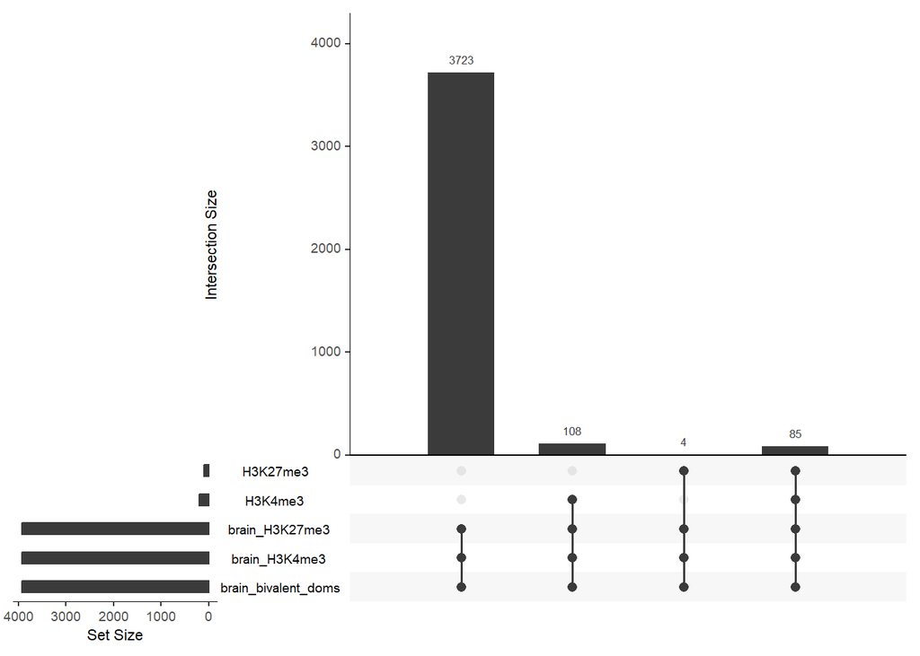

```r
regionUpset(peaks, reference = peaks$brain_bivalent_doms)
```

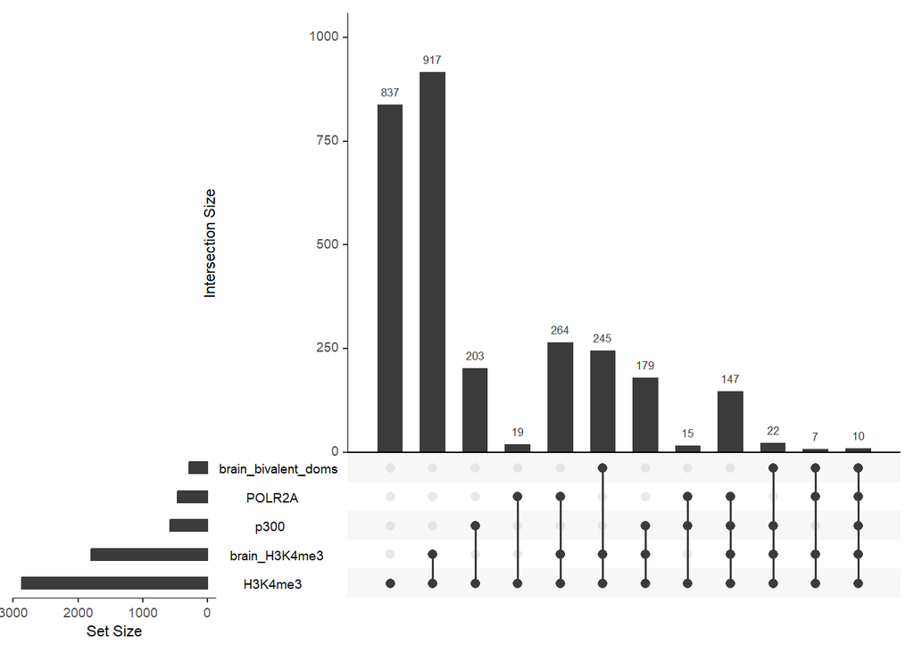

```r
regionUpset(peaks, reference = peaks$H3K4me3)
```